# JMJPFU-Ensemble model

In this Notebook we will try an ensemble method. In this method we will try stacking various algorithms and check out on the reults. We will be using the caret package for the ensemble method.

### Initial Tasks : Setting up the Library functions

```r
library(caretEnsemble)
```

## Step 1 : Setting the train Control parameters and training the model

In the first step, let us create some sub-models using the trainControl function

```r
results <- resamples(baseModels)
summary(results)
```

```
Call:
summary.resamples(object = results)

Models: lda, rpart, knn, svmRadial
Number of resamples: 30

Accuracy
            Min. 1st Qu. Median   Mean 3rd Qu.   Max. NA's
lda       0.7951  0.8063 0.8131 0.8124  0.8195 0.8262    0
rpart     0.8547  0.8632 0.8676 0.8671  0.8696 0.8762    0
knn       0.9083  0.9167 0.9197 0.9210  0.9250 0.9328    0
svmRadial 0.8848  0.8911 0.8949 0.8962  0.9016 0.9070    0

Kappa
            Min. 1st Qu. Median   Mean 3rd Qu.   Max. NA's
lda       0.1963  0.2860 0.3087 0.3033  0.3222 0.3519    0
rpart     0.4845  0.5246 0.5362 0.5370  0.5491 0.5805    0
knn       0.7214  0.7501 0.7583 0.7632  0.7766 0.7989    0
svmRadial 0.6335  0.6545 0.6690 0.6713  0.6874 0.7134    0
```

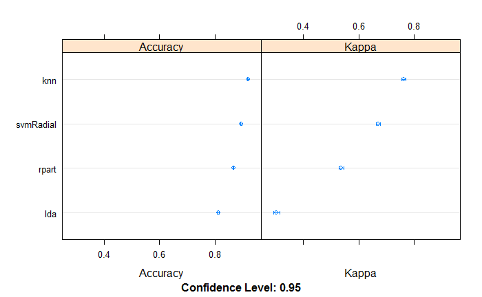

```r
dotplot(results)
```

## Step2 : Correlations checking between various model

Let us now observe the correlations between the various algorithms used

```r
modelCor(results)
```

```
                 lda       rpart         knn  svmRadial
lda       1.00000000  0.24979689  0.29901490 0.07143995
rpart     0.24979689  1.00000000 -0.07004092 0.04468439
knn       0.29901490 -0.07004092  1.00000000 0.10808290
svmRadial 0.07143995  0.04468439  0.10808290 1.00000000
```

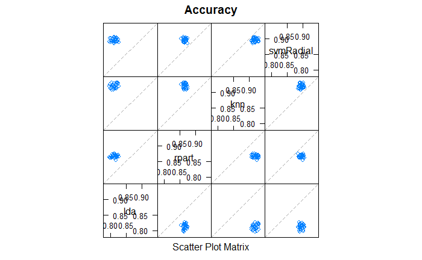

```r
splom(results)
```

So as seen from the results, all the models have very low correlation between them which is good.

### Step 3 : Stacking each model one by one

```r
stackNb <- caretStack(baseModels,method="rf",metric=metric,trControl=stackControl)
```

```
Error in check_caretList_model_types(list_of_models) :
  Not yet implemented for multiclass problems
```

When trying the stacking algorithm, it seems that it will work only for binary classification problems and not for multiclass problems.

### To get list of all models supported by Caret

```r
names(getModelInfo())
```

[output not shown]

[output cut: 31 more lines]

To see the type of models supported by a method the below can be used

```r
getModelInfo()$nb$type
```

```
[1] "Classification"
```

```r
getModelInfo()$svmPoly$type
```

```
[1] "Regression"     "Classification"
```

Let us now attempt another method of Ensemble as given in the link below

http://amunategui.github.io/blending-models/

Another good reference on caret package and some other methods

https://www.r-bloggers.com/cross-validation-for-predictive-analytics-using-r/

In this method of emsembled data, what is done is the following

1. Data is split into three sets ( One for ensemble, one for training and one for testing)
2. A baseline model is created seperately
3. Three seperate models are created ( You can create as many models as require)
4. Three seperate prediction are created for the above three seperate models on the same dataset
5. The predictions are made as seperate features
6. A new model is created with the predictions in the earlier step as features
7. The new model is then tested on the test set.

The above process is tested as below.

### Step1 : Preparing seperate data sets for the three purposes

```r
table(ensembleData$label)
```

```
        FailurePoint         NormalPeriod PeriodbeforeFailure1 PeriodbeforeFailure2 PeriodbeforeFailure3
                  84                 2759                   69                   78                   72
PeriodbeforeFailure4 PeriodbeforeFailure5 PeriodbeforeFailure6 PeriodbeforeFailure7
                  94                   84                   79                   82
```

```r
table(blenderData$label)
```

```
        FailurePoint         NormalPeriod PeriodbeforeFailure1 PeriodbeforeFailure2 PeriodbeforeFailure3
                  98                 2743                   90                   80                   77
PeriodbeforeFailure4 PeriodbeforeFailure5 PeriodbeforeFailure6 PeriodbeforeFailure7
                  70                   83                   80                   80
```

```r
table(testingData$label)
```

```
        FailurePoint         NormalPeriod PeriodbeforeFailure1 PeriodbeforeFailure2 PeriodbeforeFailure3
                  82                 2736                   88                   97                   79
PeriodbeforeFailure4 PeriodbeforeFailure5 PeriodbeforeFailure6 PeriodbeforeFailure7
                  69                   89                   81                   80
```

The data has been split and the distribution of classes are also reasonable.

Let us now assign the outcome to label and the other variables to predictors

```r
predictors
```

```
 [1] "featDischarge" "conSlope"      "dodMin"        "Dod50"         "Dod85"         "Dodtop"        "conDrop"
 [8] "con50"         "con80"         "contop"        "voltSD"
```

## Step 2 : Creating the train control and making the benchmark model

```r
trainCon <- trainControl(method="repeatedcv",number=10,repeats=3)
# Use the blender data for baselining
test_model <- train(blenderData[,predictors],blenderData[,'label'],method='gbm',metric='Accuracy',trControl=trainCon)
```

Let us use the model to predict a baseline prediction

```r
preds <- predict(object=test_model,testingData[,predictors])

confusionMatrix(testingData[,'label'],preds)
```

[output not shown]

### Step 3 : Trying out the ensemble model

Let us now create three ensemble models on the ensemble data set

```r
modelNB <- train(ensembleData[,predictors],ensembleData[,'label'],method='nb',trControl = trainCon)

modelRF <- train(ensembleData[,predictors],ensembleData[,'label'],method='rf',trControl = trainCon)

modelTreebag <- train(ensembleData[,predictors],ensembleData[,'label'],method='treebag',trControl=trainCon)
```

After these three models are trained, we use these models to predict on the blender data and also the testing data

Now let us train a final blending model on the old data

```r
predictors <- names(blenderData)[names(blenderData) != 'label']

finalBlendModel <- train(blenderData[,predictors],blenderData[,'label'],method='gbm',trControl = trainCon)
```

Let us now do some prediction with the testing data and see how the predictions fare with the new model.

```r
preds <- predict(object=finalBlendModel,testingData[,predictors])
confusionMatrix(testingData[,'label'],preds)
```

```
Confusion Matrix and Statistics

                      Reference
Prediction             FailurePoint NormalPeriod PeriodbeforeFailure1 PeriodbeforeFailure2 PeriodbeforeFailure3
  FailurePoint                   79            0                    3                    0                    0
  NormalPeriod                    0         2730                    0                    0                    0
  PeriodbeforeFailure1            0            2                   78                    1                    6
  PeriodbeforeFailure2            0            5                   19                   67                    5
  PeriodbeforeFailure3            0            0                   19                    0                   55
  PeriodbeforeFailure4            0            0                    0                    0                    0
  PeriodbeforeFailure5            0            1                   14                    1                   18
  PeriodbeforeFailure6            0            0                    0                    0                    0
  PeriodbeforeFailure7            0            2                    0                    0                    0
                      Reference
Prediction             PeriodbeforeFailure4 PeriodbeforeFailure5 PeriodbeforeFailure6 PeriodbeforeFailure7
  FailurePoint                            0                    0                    0                    0
  NormalPeriod                            5                    0                    1                    0
  PeriodbeforeFailure1                    0                    1                    0                    0
  PeriodbeforeFailure2                    0                    1                    0                    0
  PeriodbeforeFailure3                    0                    5                    0                    0
  PeriodbeforeFailure4                   69                    0                    0                    0
  PeriodbeforeFailure5                    0                   55                    0                    0
  PeriodbeforeFailure6                    0                    0                   81                    0
  PeriodbeforeFailure7                    0                    0                    0                   78

Overall Statistics

               Accuracy : 0.968
                 95% CI : (0.9615, 0.9736)
    No Information Rate : 0.8056
    P-Value [Acc > NIR] : < 2.2e-16

                  Kappa : 0.9077
 Mcnemar's Test P-Value : NA

Statistics by Class:

                     Class: FailurePoint Class: NormalPeriod Class: PeriodbeforeFailure1 Class: PeriodbeforeFailure2
Sensitivity                      1.00000              0.9964                     0.58647                     0.97101
Specificity                      0.99910              0.9909                     0.99694                     0.99100
```

[output cut: 9 more lines]

```
Pos Pred Value                           0.69620                     1.00000                     0.61798
Neg Pred Value                           0.99127                     0.99850                     0.99789
Prevalence                               0.02470                     0.02176                     0.01823
Detection Rate                           0.01617                     0.02029                     0.01617
Detection Prevalence                     0.02323                     0.02029                     0.02617
Balanced Accuracy                        0.82376                     0.96622                     0.93846
                     Class: PeriodbeforeFailure6 Class: PeriodbeforeFailure7
Sensitivity                              0.98780                     1.00000
Specificity                              1.00000                     0.99940
Pos Pred Value                           1.00000                     0.97500
Neg Pred Value                           0.99970                     1.00000
Prevalence                               0.02411                     0.02293
Detection Rate                           0.02382                     0.02293
Detection Prevalence                     0.02382                     0.02352
Balanced Accuracy                        0.99390                     0.99970
```

So as seen from the results, the accuracy has improved to around 97% with the ensemble methods. This is a good method to try and to explore further.

1. Another method to actually try out is to include the probability of each class as seperate features.